# ADP Part 02

#### for / while

```r
for (year in c(2015:2017)) {
  print(paste("This year is", year))
}
```

```
## [1] "This year is 2015"
## [1] "This year is 2016"
## [1] "This year is 2017"
```

```r
year = 2015
while(year <= 2017) {
  print(paste("This year is", year))
  year <- year + 1
}
```

```
## [1] "This year is 2015"
## [1] "This year is 2016"
## [1] "This year is 2017"
```

#### 변수 추가

- transform(데이터프레임, “추가할변수 이름”, “추가할변수”)

```r
data(iris)
iris$ID1 <- 1:nrow(iris)
iris["ID2"] <- ifelse(iris$ID1%%2 == 0, "A", "B")
head(transform(iris, ID3=iris$ID1*2))
```

| Sepal.Length | Sepal.Width | Petal.Length | Petal.Width | Species | ID1 | ID2 | ID3 |
| --- | --- | --- | --- | --- | --- | --- | --- |
| 5.1 | 3.5 | 1.4 | 0.2 | setosa | 1 | B | 2 |
| 4.9 | 3.0 | 1.4 | 0.2 | setosa | 2 | A | 4 |
| 4.7 | 3.2 | 1.3 | 0.2 | setosa | 3 | B | 6 |
| 4.6 | 3.1 | 1.5 | 0.2 | setosa | 4 | A | 8 |
| 5.0 | 3.6 | 1.4 | 0.2 | setosa | 5 | B | 10 |
| 5.4 | 3.9 | 1.7 | 0.4 | setosa | 6 | A | 12 |

```r
score_df <- within(score_df, {
  grade = character(0)         # 새로운 변수의 데이터 타입 지정 (생략 가능)
  grade[ score < 60 ] = "가"   # score가 60미만인 경우 grade에 “가” 입력
  grade[ score >=60 & score < 70 ] = "양"
  grade[ score >=70 & score < 80 ] = "미"
  grade[ score >=80 & score < 90 ] = "우"
  grade[ score >=90 ] = "수"
  grade = factor(grade, level = c("수", "우", "미", "양", "가"))
  # grade변수를 "수", "우", "미", "양", "가"의 범주로 이루어진 팩터로 변환
})
```

#### 변수축소 (PCA)

- prcomp : 자료 행렬을 특이값 분해(SVD) 방법

```r
library(datasets) ; data("USArrests")
prcomp(USArrests, center=T, # 데이터 중심이 0이 되게 함
       scale.=F) # 데이터를 표준화
```

- princomp : 공분산행렬/상관행렬의 고유벡터 사용
- 공분산행렬은 변수의 측정 단위 반영 / 상관행렬은 변수의 측정 단위 표준화(변수들 간 척도 차이가 클 떄)

```r
princomp(USArrests, cor = F, # F : 공분산행렬 사용 / T : 상관행렬 사용
         scores = T)
```

```r
US.prin <- princomp(USArrests, cor = T)
summary(US.prin)
```

```
## Importance of components:
##                           Comp.1    Comp.2    Comp.3     Comp.4
## Standard deviation     1.5748783 0.9948694 0.5971291 0.41644938
## Proportion of Variance 0.6200604 0.2474413 0.0891408 0.04335752
## Cumulative Proportion  0.6200604 0.8675017 0.9566425 1.00000000
```

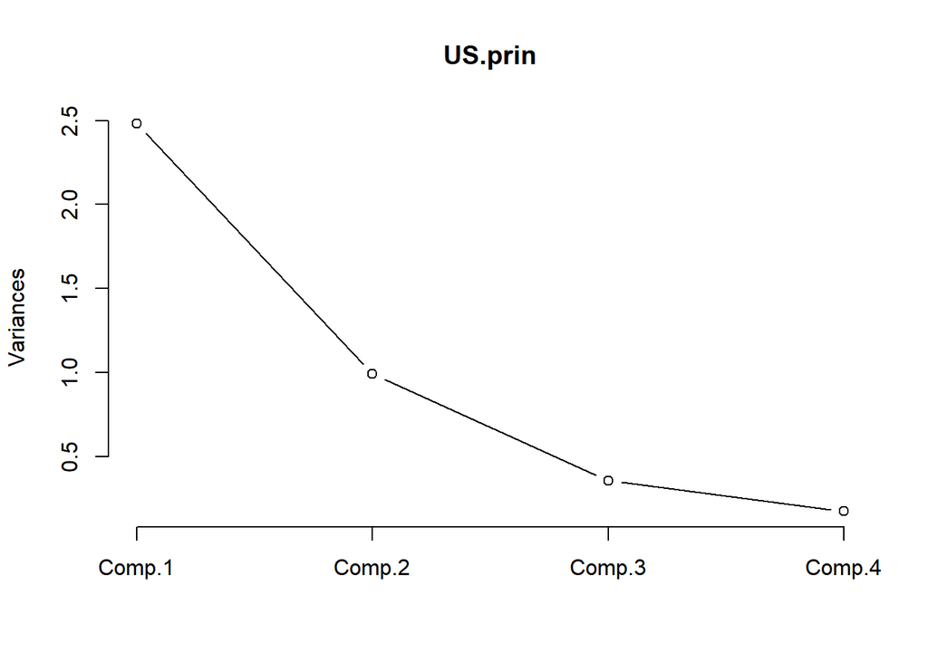

```r
plot(US.prin, type = "l") # Screeplot
```

```r
US.prin$loadings # 주성분계수
```

```
##
## Loadings:
##          Comp.1 Comp.2 Comp.3 Comp.4
## Murder    0.536  0.418  0.341  0.649
## Assault   0.583  0.188  0.268 -0.743
## UrbanPop  0.278 -0.873  0.378  0.134
## Rape      0.543 -0.167 -0.818
##
##                Comp.1 Comp.2 Comp.3 Comp.4
## SS loadings      1.00   1.00   1.00   1.00
## Proportion Var   0.25   0.25   0.25   0.25
## Cumulative Var   0.25   0.50   0.75   1.00
```

```r
US.prin$scores[1:5,] # 주성분점수
```

```
##                Comp.1     Comp.2      Comp.3     Comp.4
## Alabama     0.9855659  1.1333924  0.44426879  0.1562671
## Alaska      1.9501378  1.0732133 -2.04000333 -0.4385834
## Arizona     1.7631635 -0.7459568 -0.05478082 -0.8346529
## Arkansas   -0.1414203  1.1197968 -0.11457369 -0.1828109
## California  2.5239801 -1.5429340 -0.59855680 -0.3419965
```

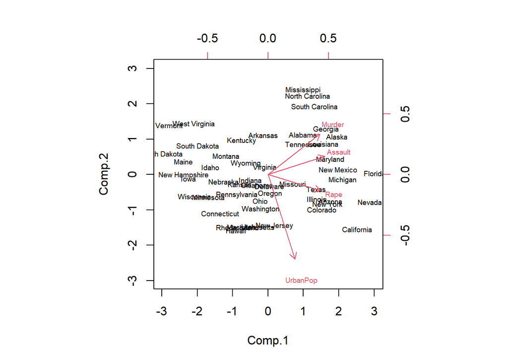

```r
biplot(US.prin, scale = 0, cex = 0.6)
```

#### 요인분석 - 요인분석 : 변수들 간의 상관관계 고려, 서로 유사한 변수들을 묶어 새로운 잠재요인 추출 (PCA, 공통요인분석)

```r
data(swiss)
Min <- apply(swiss, 2, min) ; Max <- apply(swiss, 2, max)
swiss_fa <- scale(swiss, center = Min, scale = (Max-Min)) # Min-Max 정규화
factanal(swiss_fa, factors = 3) # 요인 개수를 3으로 지정
```

```
##
## Call:
## factanal(x = swiss_fa, factors = 3)
##
## Uniquenesses:
##        Fertility      Agriculture      Examination        Education
##            0.005            0.286            0.213            0.114
##         Catholic Infant.Mortality
##            0.083            0.743
##
## Loadings:
##                  Factor1 Factor2 Factor3
## Fertility        -0.512   0.203   0.832
## Agriculture      -0.774   0.312  -0.129
## Examination       0.751  -0.423  -0.211
## Education         0.901          -0.262
## Catholic         -0.186   0.913   0.220
## Infant.Mortality                  0.500
##
##                Factor1 Factor2 Factor3
## SS loadings      2.273   1.164   1.120
## Proportion Var   0.379   0.194   0.187
## Cumulative Var   0.379   0.573   0.759
##
## The degrees of freedom for the model is 0 and the fit was 1e-04
```

```r
# 누적 분산비 = 75.9%, 3개의 요인은 전체의 75.9%를 설명
```

#### 표준화 (Z-score)

```r
scale(swiss, center = T, # center = T이면 데이터에서 평균을 뺌
      scale = T) # scale = T이면 표준편차로 나눔 / F면 어떤 값으로도 나누지 않음
# center = F, scale = T이면 데이터를 제곱평균제곱근(RMS)로 나눔
```

#### 정규화 (X-Min) / (Max-Min)

```r
Min <- apply(swiss, 2, min) ; Max <- apply(swiss, 2, max)
swiss_fa <- scale(swiss, center = Min, scale = (Max-Min))
```

#### 데이터 결합 및 요약

- rbind(data1, data2) : 행결합
- cbind(data1, data2) : 열결합
- merge(x, y, by = “기준열”) : 데이터 병합

```r
id_name <- data.frame(id = c("c01","c02","c03","c04","c05", "c06", "c07"),
                      last_name = c("Lee", "Kim", "Choi", "Park", "Lim" , "Bae", "Kim"))
id_number <- data.frame(id = c("c03", "c04", "c05", "c06", "c07", "c08", "c09"),
                        number = c(3, 1, 0, 7, 3, 4, 1))
```

```r
merge(id_name, id_number, by = "id") # "id"열 기준 inner join
```

```
##    id last_name number
## 1 c03      Choi      3
## 2 c04      Park      1
## 3 c05       Lim      0
## 4 c06       Bae      7
## 5 c07       Kim      3
```

```r
merge(id_name, id_number, by = "id", all = T) # "id"열 기준 outer join
```

```
##    id last_name number
## 1 c01       Lee     NA
## 2 c02       Kim     NA
## 3 c03      Choi      3
## 4 c04      Park      1
## 5 c05       Lim      0
## 6 c06       Bae      7
## 7 c07       Kim      3
## 8 c08      <NA>      4
## 9 c09      <NA>      1
```

```r
merge(id_name, id_number, by = "id", all.x = T) # "id"열 기준 left outer join
```

```
##    id last_name number
## 1 c01       Lee     NA
## 2 c02       Kim     NA
## 3 c03      Choi      3
## 4 c04      Park      1
## 5 c05       Lim      0
## 6 c06       Bae      7
## 7 c07       Kim      3
```

```r
merge(id_name, id_number, by = "id", all.y = T) # "id"열 기준 right outer join
```

```
##    id last_name number
## 1 c03      Choi      3
## 2 c04      Park      1
## 3 c05       Lim      0
## 4 c06       Bae      7
## 5 c07       Kim      3
## 6 c08      <NA>      4
## 7 c09      <NA>      1
```

#### 데이터 요약

```r
aggregate(Sepal.Width ~ Species, iris, mean)
```

```
##      Species Sepal.Width
## 1     setosa       3.428
## 2 versicolor       2.770
## 3  virginica       2.974
```

```r
# iris 데이터의 Species별 Sepal.Width의 평균
```

#### table

```r
Titanic <- as.data.frame(Titanic)
table(Titanic$Class)
```

```
##
##  1st  2nd  3rd Crew
##    8    8    8    8
```

```r
table(Titanic$Class, Titanic$Survived)
```

```
##
##        No Yes
##   1st   4   4
##   2nd   4   4
##   3rd   4   4
##   Crew  4   4
```

#### prop.table

```r
prop.table(table(Titanic$Class, Titanic$Survived)) # 비율
```

```
##
##           No   Yes
##   1st  0.125 0.125
##   2nd  0.125 0.125
##   3rd  0.125 0.125
##   Crew 0.125 0.125
```

```r
prop.table(table(Titanic$Class, Titanic$Survived), 1) # 행 별 비율
```

```
##
##         No Yes
##   1st  0.5 0.5
##   2nd  0.5 0.5
##   3rd  0.5 0.5
##   Crew 0.5 0.5
```

```r
prop.table(table(Titanic$Class, Titanic$Survived), 2) # 열 별 비율
```

```
##
##          No  Yes
##   1st  0.25 0.25
##   2nd  0.25 0.25
##   3rd  0.25 0.25
##   Crew 0.25 0.25
```

#### apply 계열 함수

- apply

```r
apply(iris[,1:4], # iris 데이터의 1~4열에 대해서
      2, # 1은 행 방향 / 2는 열 방향으로 계산
      mean) # 평균 계산
```

```
## Sepal.Length  Sepal.Width Petal.Length  Petal.Width
##     5.843333     3.057333     3.758000     1.199333
```

- lapply : 결과를 리스트로 변환, 데이터프레임에 대해서는 열 방향으로 함수 적용

```r
a <- c(1,2,3)
lapply(a, FUN = function(x){x^2})
```

```
## [[1]]
## [1] 1
##
## [[2]]
## [1] 4
##
## [[3]]
## [1] 9
```

- sapply : 결과를 벡터 혹은 행렬로 변환, 데이터프레임에 대해서는 열별로 함수 적용

```r
sapply(iris, class)
```

```
## Sepal.Length  Sepal.Width Petal.Length  Petal.Width      Species          ID1
##    "numeric"    "numeric"    "numeric"    "numeric"     "factor"    "integer"
##          ID2
##  "character"
```

- vapply : sapply와 유사, 출력결과의 형태를 사용자가 직접 지정

```r
test <- c(1:100) ; fivenum(test)
```

```
## [1]   1.0  25.5  50.5  75.5 100.0
```

```r
test <- list(test) ; test2 <- vapply(test,
                                     fivenum, # 적용할 함수
                                     c("Min" = 0, "Q1" = 0, "Median" = 0, "Q3" = 0, "Max" = 0)) # 함수 실행 후 출력되는 값의 형태
test2
```

```
##         [,1]
## Min      1.0
## Q1      25.5
## Median  50.5
## Q3      75.5
## Max    100.0
```

- mapply : sapply의 확장, 여러개의 인자를 필요로 하는 함수를 여러 데이터에 적용할 경우, 다수의 요소를 한 번에 적용 가능

```r
rep(1,4) ; rep(2,3) ; rep(3,2) ; rep(4,1)
```

```
## [1] 1 1 1 1
```

```
## [1] 2 2 2
```

```
## [1] 3 3
```

```
## [1] 4
```

```r
mapply(rep, # 적용함수
       c(1:4), c(4:1))
```

```
## [[1]]
## [1] 1 1 1 1
##
## [[2]]
## [1] 2 2 2
##
## [[3]]
## [1] 3 3
##
## [[4]]
## [1] 4
```

- tapply : 각 그룹별로 함수를 적용

```r
library(googleVis)
```

| Fruit | Year | Location | Sales | Expenses | Profit | Date |
| --- | --- | --- | --- | --- | --- | --- |
| Apples | 2008 | West | 98 | 78 | 20 | 2008-12-31 |
| Apples | 2009 | West | 111 | 79 | 32 | 2009-12-31 |
| Apples | 2010 | West | 89 | 76 | 13 | 2010-12-31 |
| Oranges | 2008 | East | 96 | 81 | 15 | 2008-12-31 |
| Bananas | 2008 | East | 85 | 76 | 9 | 2008-12-31 |
| Oranges | 2009 | East | 93 | 80 | 13 | 2009-12-31 |

```r
tapply(Fruits$Sales, Fruits$Fruit, mean)
```

```
##   Apples  Bananas  Oranges
## 99.33333 86.66667 95.66667
```

```r
# Fruit별 Sales의 평균
```

```r
tapply(Fruits$Profit, Fruits$Location == "West", mean)
```

```
##    FALSE     TRUE
## 11.66667 21.66667
```

```r
# Location이 West인 것과 아닌 것으로 그룹을 지정하여, Profit의 평균
```

#### plyr

- a : array / l : list / d : data frame / _ : 아무런 출력을 하지 않음
- adply : 배열을 입력받아 함수를 적용한 후 데이터 프레임으로 반환

```r
library(plyr)
```

```r
head(adply(iris,1,
      function(row){
        data.frame(setosa_PL1.5=
                     c(ifelse(row$Petal.Length<1.5 &
                                row$Species=="setosa", "1", "0"))
        )
      })) # 변수명을 "setosa_PL1.5"로 지정하여 데이터프레임으로 반환
```

| Sepal.Length | Sepal.Width | Petal.Length | Petal.Width | Species | ID1 | ID2 | setosa_PL1.5 |
| --- | --- | --- | --- | --- | --- | --- | --- |
| 5.1 | 3.5 | 1.4 | 0.2 | setosa | 1 | B | 1 |
| 4.9 | 3.0 | 1.4 | 0.2 | setosa | 2 | A | 1 |
| 4.7 | 3.2 | 1.3 | 0.2 | setosa | 3 | B | 1 |
| 4.6 | 3.1 | 1.5 | 0.2 | setosa | 4 | A | 0 |
| 5.0 | 3.6 | 1.4 | 0.2 | setosa | 5 | B | 1 |
| 5.4 | 3.9 | 1.7 | 0.4 | setosa | 6 | A | 0 |

- ddply : 인자에 지정한 변수들로 데이터를 그룹화한 후 그룹별로 함수를 적용하고 결과값 반환

```r
ddply(iris, .(Species, Petal.Length < 1.5), function(sub){
  data.frame(
    mean_SL=mean(sub$Sepal.Length), mean_SW=mean(sub$Sepal.Width),
    mean_PL=mean(sub$Petal.Length), mean_PW=mean(sub$Petal.Width))
})
# Petal.Length가 1.5 미만인 데이터에 대해 변수별 평균
```

| Species | Petal.Length < 1.5 | mean_SL | mean_SW | mean_PL | mean_PW |
| --- | --- | --- | --- | --- | --- |
| setosa | FALSE | 5.107692 | 3.515385 | 1.588461 | 0.2730769 |
| setosa | TRUE | 4.895833 | 3.333333 | 1.325000 | 0.2166667 |
| versicolor | FALSE | 5.936000 | 2.770000 | 4.260000 | 1.3260000 |
| virginica | FALSE | 6.588000 | 2.974000 | 5.552000 | 2.0260000 |

- transform : 원본 데이터에 새로운 연산 결과를 담은 칼럼을 추가하여 함께 출력

```r
ddply(baseball, .(id), transform, avgG = sum(g)/length(year))
# 원본데이터에 id별 avgG칼럼 추가
```

| id | year | stint | team | lg | g | ab | r | h | X2b | X3b | hr | rbi | sb | cs | bb | so | ibb | hbp | sh | sf | gidp | avgG |
| --- | --- | --- | --- | --- | --- | --- | --- | --- | --- | --- | --- | --- | --- | --- | --- | --- | --- | --- | --- | --- | --- | --- |
| aaronha01 | 1954 | 1 | ML1 | NL | 122 | 468 | 58 | 131 | 27 | 6 | 13 | 69 | 2 | 2 | 28 | 39 | NA | 3 | 6 | 4 | 13 | 143.3913 |
| aaronha01 | 1955 | 1 | ML1 | NL | 153 | 602 | 105 | 189 | 37 | 9 | 27 | 106 | 3 | 1 | 49 | 61 | 5 | 3 | 7 | 4 | 20 | 143.3913 |
| aaronha01 | 1956 | 1 | ML1 | NL | 153 | 609 | 106 | 200 | 34 | 14 | 26 | 92 | 2 | 4 | 37 | 54 | 6 | 2 | 5 | 7 | 21 | 143.3913 |
| aaronha01 | 1957 | 1 | ML1 | NL | 151 | 615 | 118 | 198 | 27 | 6 | 44 | 132 | 1 | 1 | 57 | 58 | 15 | 0 | 0 | 3 | 13 | 143.3913 |
| aaronha01 | 1958 | 1 | ML1 | NL | 153 | 601 | 109 | 196 | 34 | 4 | 30 | 95 | 4 | 1 | 59 | 49 | 16 | 1 | 0 | 3 | 21 | 143.3913 |
| aaronha01 | 1959 | 1 | ML1 | NL | 154 | 629 | 116 | 223 | 46 | 7 | 39 | 123 | 8 | 0 | 51 | 54 | 17 | 4 | 0 | 9 | 19 | 143.3913 |

- mutate : 원본 데이터에 여러 칼럼 추가

```r
ddply(baseball, .(id), mutate, avgG=sum(g)/length(year), avgG_RND=round(avgG))
```

| id | year | stint | team | lg | g | ab | r | h | X2b | X3b | hr | rbi | sb | cs | bb | so | ibb | hbp | sh | sf | gidp | avgG | avgG_RND |
| --- | --- | --- | --- | --- | --- | --- | --- | --- | --- | --- | --- | --- | --- | --- | --- | --- | --- | --- | --- | --- | --- | --- | --- |
| aaronha01 | 1954 | 1 | ML1 | NL | 122 | 468 | 58 | 131 | 27 | 6 | 13 | 69 | 2 | 2 | 28 | 39 | NA | 3 | 6 | 4 | 13 | 143.3913 | 143 |
| aaronha01 | 1955 | 1 | ML1 | NL | 153 | 602 | 105 | 189 | 37 | 9 | 27 | 106 | 3 | 1 | 49 | 61 | 5 | 3 | 7 | 4 | 20 | 143.3913 | 143 |
| aaronha01 | 1956 | 1 | ML1 | NL | 153 | 609 | 106 | 200 | 34 | 14 | 26 | 92 | 2 | 4 | 37 | 54 | 6 | 2 | 5 | 7 | 21 | 143.3913 | 143 |
| aaronha01 | 1957 | 1 | ML1 | NL | 151 | 615 | 118 | 198 | 27 | 6 | 44 | 132 | 1 | 1 | 57 | 58 | 15 | 0 | 0 | 3 | 13 | 143.3913 | 143 |
| aaronha01 | 1958 | 1 | ML1 | NL | 153 | 601 | 109 | 196 | 34 | 4 | 30 | 95 | 4 | 1 | 59 | 49 | 16 | 1 | 0 | 3 | 21 | 143.3913 | 143 |
| aaronha01 | 1959 | 1 | ML1 | NL | 154 | 629 | 116 | 223 | 46 | 7 | 39 | 123 | 8 | 0 | 51 | 54 | 17 | 4 | 0 | 9 | 19 | 143.3913 | 143 |

- summarise : 데이터의 요약 정보 생성

```r
ddply(baseball, .(id), summarise, year_fin = max(year))
# id별 요약변수 year_fin 생성
```

| id | year_fin |
| --- | --- |
| aaronha01 | 1976 |
| abernte02 | 1972 |
| adairje01 | 1970 |
| adamsba01 | 1926 |
| adamsbo03 | 1959 |
| adcocjo01 | 1966 |

- subset : 조건을 만족하는 행들만 출력

```r
ddply(baseball, .(id), subset,
      year == max(year), # subset 조건
      select = c("id", "year", "stint", "team", "lg", "g"))
```

| id | year | stint | team | lg | g |
| --- | --- | --- | --- | --- | --- |
| aaronha01 | 1976 | 1 | ML4 | AL | 85 |
| abernte02 | 1972 | 1 | KCA | AL | 45 |
| adairje01 | 1970 | 1 | KCA | AL | 7 |
| adamsba01 | 1926 | 1 | PIT | NL | 19 |
| adamsbo03 | 1959 | 1 | CHN | NL | 3 |
| adcocjo01 | 1966 | 1 | CAL | AL | 83 |

#### dplyr

- %>% 기호로 연결하여 중첩사용 가능
- filter : 조건에 맞는 행들을 추출

```r
library(dplyr) ; library(MASS)
```

```r
Cars93 %>% filter((Manufacturer == "Audi" | Manufacturer == "BMW") & EngineSize >= 2.4)
```

| Manufacturer | Model | Type | Min.Price | Price | Max.Price | MPG.city | MPG.highway | AirBags | DriveTrain | Cylinders | EngineSize | Horsepower | RPM | Rev.per.mile | Man.trans.avail | Fuel.tank.capacity | Passengers | Length | Wheelbase | Width | Turn.circle | Rear.seat.room | Luggage.room | Weight | Origin | Make |
| --- | --- | --- | --- | --- | --- | --- | --- | --- | --- | --- | --- | --- | --- | --- | --- | --- | --- | --- | --- | --- | --- | --- | --- | --- | --- | --- |
| Audi | 90 | Compact | 25.9 | 29.1 | 32.3 | 20 | 26 | Driver only | Front | 6 | 2.8 | 172 | 5500 | 2280 | Yes | 16.9 | 5 | 180 | 102 | 67 | 37 | 28 | 14 | 3375 | non-USA | Audi 90 |
| Audi | 100 | Midsize | 30.8 | 37.7 | 44.6 | 19 | 26 | Driver & Passenger | Front | 6 | 2.8 | 172 | 5500 | 2535 | Yes | 21.1 | 6 | 193 | 106 | 70 | 37 | 31 | 17 | 3405 | non-USA | Audi 100 |
| BMW | 535i | Midsize | 23.7 | 30.0 | 36.2 | 22 | 30 | Driver only | Rear | 4 | 3.5 | 208 | 5700 | 2545 | Yes | 21.1 | 4 | 186 | 109 | 69 | 39 | 27 | 13 | 3640 | non-USA | BMW 535i |

- select : 특정 열만을 추출

```r
Cars93 %>%
  filter((Manufacturer == "Chevrolet" | Manufacturer == "Volkswagen") & Price >= 10) %>%
  dplyr::select(Manufacturer, Model, Type, Price)
```

| Manufacturer | Model | Type | Price |
| --- | --- | --- | --- |
| Chevrolet | Cavalier | Compact | 13.4 |
| Chevrolet | Corsica | Compact | 11.4 |
| Chevrolet | Camaro | Sporty | 15.1 |
| Chevrolet | Lumina | Midsize | 15.9 |
| Chevrolet | Lumina_APV | Van | 16.3 |
| Chevrolet | Astro | Van | 16.6 |

- group_by : 지정한 변수들을 기준으로 데이터 그룹화
- summarise : 통계치 계산 (mean / median / sd / min / max / sum / n : 행의 개수 세기)

```r
Cars93 %>% group_by(Manufacturer) %>%
  summarise(mean_Price = mean(Price), max_Weight = max(Weight))
# Cars93의 Manufacturer별 Price의 평균과 Weight의 최댓값을 산출한 뒤 각각 mean_Price, max_Weight로 지정하여 출력
```

| Manufacturer | mean_Price | max_Weight |
| --- | --- | --- |
| Acura | 24.9000 | 3560 |
| Audi | 33.4000 | 3405 |
| BMW | 30.0000 | 3640 |
| Buick | 21.6250 | 4105 |
| Cadillac | 37.4000 | 3935 |
| Chevrolet | 18.1875 | 4025 |

- mutate : 새로운 파생변수 추가

```r
Cars93 %>% mutate(Pr_level = ifelse(Price < 12, "low",
                                    ifelse(Price >= 12 & Price < 23, "middle", "high"))) %>%
  dplyr::select(Model, Price, Pr_level)
```

| Model | Price | Pr_level |
| --- | --- | --- |
| Integra | 15.9 | middle |
| Legend | 33.9 | high |
| 90 | 29.1 | high |
| 100 | 37.7 | high |
| 535i | 30.0 | high |
| Century | 15.7 | middle |

- arrange : 특정 열 기준으로 데이터를 정렬

```r
Cars93 %>%
  filter(Type %in% c("Midsize", "Small")) %>%
  dplyr::select(Model, Type, Weight, Price) %>%
  group_by(Type) %>%
  mutate(Weight_lv = ifelse(Weight < median(Weight), "low", "high")) %>%
  arrange(Price) # arrange(desc(Price))면 내림차순
```

| Model | Type | Weight | Price | Weight_lv |
| --- | --- | --- | --- | --- |
| Festiva | Small | 1845 | 7.4 | low |
| Excel | Small | 2345 | 8.0 | high |
| 323 | Small | 2325 | 8.3 | low |
| Metro | Small | 1695 | 8.4 | low |
| Justy | Small | 2045 | 8.4 | low |
| Swift | Small | 1965 | 8.6 | low |

- {left, right, inner, full}_join

```r
NAME<-data.frame(code=c("A01","A02","A03"), name=c("coffee","cake","cookie"))
PRICE<-data.frame(code=c("A01","A02","A04"), price=c(3000, 4000, 3000))
left_join(NAME, PRICE, by = "code")
```

```
##   code   name price
## 1  A01 coffee  3000
## 2  A02   cake  4000
## 3  A03 cookie    NA
```

```r
right_join(NAME, PRICE, by = "code")
```

```
##   code   name price
## 1  A01 coffee  3000
## 2  A02   cake  4000
## 3  A04   <NA>  3000
```

```r
inner_join(NAME, PRICE, by = "code")
```

```
##   code   name price
## 1  A01 coffee  3000
## 2  A02   cake  4000
```

```r
full_join(NAME, PRICE, by = "code")
```

```
##   code   name price
## 1  A01 coffee  3000
## 2  A02   cake  4000
## 3  A03 cookie    NA
## 4  A04   <NA>  3000
```

- bind_rows / bind_cols : 행/열을 이어 붙여 결합
- rbind는 열 이름이 다르면 제대로 결합되지 않는 반변, bind_rows는 열 이름이 다르더라도 빈자리는 NA값으로 채워지면서 데이터가 결합

```r
A <- data.frame(code = c(1,2), name = c("coffee", "cake"))
B <- data.frame(code = c(3,4), name = c("cookie", "juice"))
C <- data.frame(code = 5, name = "bread")
dplyr::bind_rows(A,B,C, .id = "id")
```

```
##   id code   name
## 1  1    1 coffee
## 2  1    2   cake
## 3  2    3 cookie
## 4  2    4  juice
## 5  3    5  bread
```

#### reshape2

- melt

```r
library(reshape2)
```

```r
air_melt <- melt(airquality, id.vars = c("Month", "Day"), na.rm=T)
# Month와 Day를 식별자로, 나머지 변수와 변수 값은 데이터 내에 포함되는 형태
```

|  | Month | Day | variable | value |
| --- | --- | --- | --- | --- |
| 1 | 5 | 1 | Ozone | 41 |
| 2 | 5 | 2 | Ozone | 36 |
| 3 | 5 | 3 | Ozone | 12 |
| 4 | 5 | 4 | Ozone | 18 |
| 6 | 5 | 6 | Ozone | 28 |
| 7 | 5 | 7 | Ozone | 23 |

- dcast

```r
dcast(air_melt, Month + Day ~ variable, fun.aggregate = mean)
```

| Month | Day | Ozone | Solar.R | Wind | Temp |
| --- | --- | --- | --- | --- | --- |
| 5 | 1 | 41 | 190 | 7.4 | 67 |
| 5 | 2 | 36 | 118 | 8.0 | 72 |
| 5 | 3 | 12 | 149 | 12.6 | 74 |
| 5 | 4 | 18 | 313 | 11.5 | 62 |
| 5 | 5 | NaN | NaN | 14.3 | 56 |
| 5 | 6 | 28 | NaN | 14.9 | 66 |

#### data.table

- data.table(tag = value, …) : tag(변수명) = value(값)의 형태로 데이터 생성
- as.data.table(데이터프레임) : 데이터프레임을 데이터테이블로 변환
- tables() : 모든 데이터테이블 객체의 목록을 확인

```r
library(data.table)
```

```r
(mydata <- data.table(x = c(1:3), y = "가","나","다"))
```

```
##    x  y V3 V4
## 1: 1 가 나 다
## 2: 2 가 나 다
## 3: 3 가 나 다
```

```r
iris_dt <- as.data.table(iris)
tables()
```

```
##       NAME NROW NCOL MB
## 1: iris_dt  150    7  0
## 2:  mydata    3    4  0
##                                                                 COLS KEY
## 1: Sepal.Length,Sepal.Width,Petal.Length,Petal.Width,Species,ID1,...
## 2:                                                         x,y,V3,V4
## Total: 0MB
```

- 데이터테이블[행, 열, by = “그룹화 기준 변수”]

```r
iris_dt[iris_dt$Species == "setosa",]
iris_dt[, mean(Petal.Length), by = Species] # Species별 Petal.Length의 평균
iris_dt[Petal.Length>=1, .(mean.SL=mean(Sepal.Length), mean.SW=mean(Sepal.Width)), by=Species]
# Petal.Length값이 1이상인 행들을 Species로 그룹화 한 뒤, mean.SL, mean.SW를 변수명으로 하여 출력
```

- 새로운 변수 생성

```r
air <- as.data.table(airquality)
air[, Wind_class := ifelse(Wind >= mean(Wind), "U", "D")]; air[1:5,]
```

```
##    Ozone Solar.R Wind Temp Month Day Wind_class
## 1:    41     190  7.4   67     5   1          D
## 2:    36     118  8.0   72     5   2          D
## 3:    12     149 12.6   74     5   3          U
## 4:    18     313 11.5   62     5   4          U
## 5:    NA      NA 14.3   56     5   5          U
```

- 데이터 정렬

```r
air[, season:=ifelse(Month %in% c(12,1,2), "winter",
                     ifelse(Month %in% c(3:5), "spring",
                            ifelse(Month %in% c(6:8), "summer", "fall")))]
air[, .(Ozone_mean=mean(Ozone, na.rm=T), Solar.R_mean=mean(Solar.R, na.rm=T)),
    by=.(season)][order(Ozone_mean, decreasing = T)] ; air[1:5, ]
```

```
##    season Ozone_mean Solar.R_mean
## 1: summer   55.09836     193.5730
## 2:   fall   31.44828     167.4333
## 3: spring   23.61538     181.2963
```

```
##    Ozone Solar.R Wind Temp Month Day Wind_class season
## 1:    41     190  7.4   67     5   1          D spring
## 2:    36     118  8.0   72     5   2          D spring
## 3:    12     149 12.6   74     5   3          U spring
## 4:    18     313 11.5   62     5   4          U spring
## 5:    NA      NA 14.3   56     5   5          U spring
```

```r
# season별 Ozone과 Solar.R 변수들의 평균 산출 및 내림차순 정렬
```

- key를 활용

```r
baseball <- as.data.table(baseball)
setkey(baseball, year) # year변수를 key로 지정
baseball[J(1960)] # 1960년 데이터 조회
```

```r
baseball[J(1960), list(gmean = mean(g)), by = team][1:5]
```

```
##    team    gmean
## 1:  WS1 54.33333
## 2:  BAL 52.93333
## 3:  DET 68.76923
## 4:  CHA 78.25000
## 5:  NYA 78.36364
```

```r
# 1960년 팀별, g의 평균
```

#### 결측치

```r
air_na <- airquality[!complete.cases(airquality),] # 결측값을 포함하는 행만 저장
air_com <- airquality[complete.cases(airquality),] # 결측값을 미포함하는 행만 저장
```

- 단순 대치법 : 완전분석, 평균대치, 단순확률 대치(Hot-deck, nearest neighbor)
- 다중 대치법 : 단순 대치법을 한 번이 아닌 m번 수행하여 m개의 가상적 완전 자료를 만듬

```r
# 평균대치
airquality$Ozone <- ifelse(is.na(airquality$Ozone), mean(airquality$Ozone, na.rm = T), airquality$Ozone)
```

- DMwR
- library(DMwR)
- centralImputation(data) : 결측값 중앙값으로 대치
- centralValue(data) : 숫자 데이터의 결측값은 중앙값으로, factor 변수는 최빈값으로 - knnImputation(data, k) : k 최근접 이웃의 결과로 결측값을 대체

#### 이상치

- quantile

```r
quantile(airquality$Ozone, 0.2, na.rm = FALSE) # 20백분위수
fivenum(airquality$Ozone) # 1사분위, 2사분위, 평균, 3사분위, 최대값
IQR(airquality$Ozone) # IQR
summary(airquality$Ozone)
```

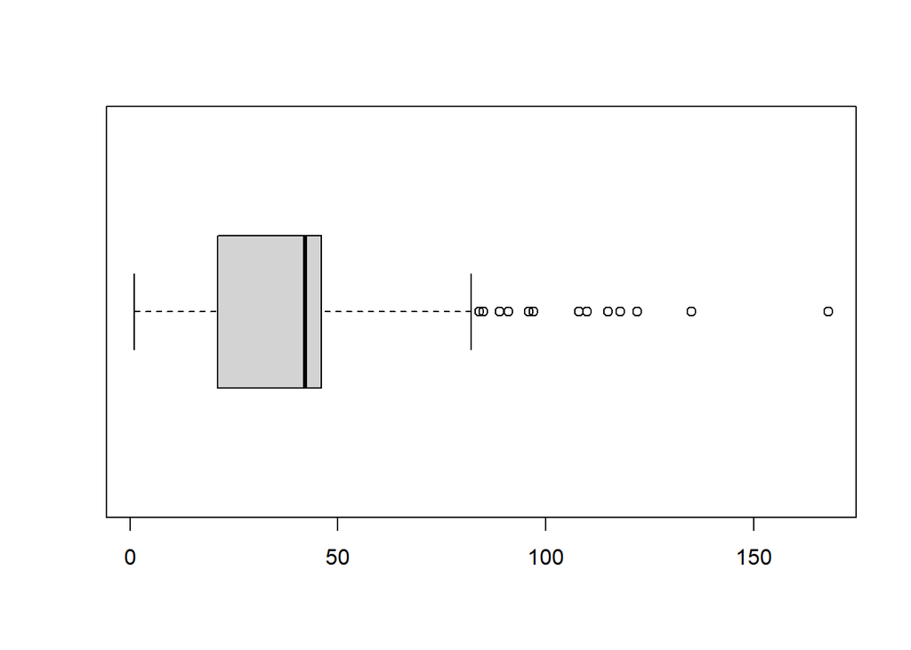

```r
OzoneBP <- boxplot(airquality$Ozone, horizontal = T) # boxplot 가로로
```

```r
OzoneBP   # 135, 168라는 이상치가 존재함을 확인할 수 있음
```

```
## $stats
##          [,1]
## [1,]  1.00000
## [2,] 21.00000
## [3,] 42.12931
## [4,] 46.00000
## [5,] 82.00000
##
## $n
## [1] 153
##
## $conf
##          [,1]
## [1,] 38.93592
## [2,] 45.32270
##
## $out
##  [1] 115 135  97  97  85 108 122  89 110 168 118  84  85  96  91
##
## $group
##  [1] 1 1 1 1 1 1 1 1 1 1 1 1 1 1 1
##
## $names
## [1] "1"
```

#### 날짜 데이터

- Date
- POSIXct
- POSIXlt
- (POSIX시간 : 유닉스 시간, 1970년 1월 1일 00:00:00부터의 경과시간을 초로 환산)

```r
(today<-Sys.Date()) # 현재 날짜
```

```
## [1] "2022-03-11"
```

```r
class(today)
```

```
## [1] "Date"
```

```r
(time<-Sys.time()) # 현재 날짜와 시간
```

```
## [1] "2022-03-11 21:50:10 KST"
```

```r
class(time)
```

```
## [1] "POSIXct" "POSIXt"
```

```r
unclass(today) # 1970년 1월 1일 이후로 경과한 일 수
```

```
## [1] 19062
```

```r
unclass(time) # 1970년 1월 1일 00:00:00 이후로 경과한 초 수를 의미
```

```
## [1] 1647003011
```

```r
as.POSIXct(unclass(time), origin="1970-01-01")
```

```
## [1] "2022-03-11 21:50:10 KST"
```

```r
# unclass한 time값을 다시 원래 날짜로
```

```r
(time <- as.POSIXlt(Sys.time()))
```

```
## [1] "2022-03-11 21:50:11 KST"
```

```r
time$year + 1900 # time$year에는 1900년 이후의 경과 년도수가 저장
```

```
## [1] 2022
```

```r
time$mon+1 # 월(mon) 추출 : 월 정보는 0-11값으로 저장
```

```
## [1] 3
```

```r
time$mday # 일(mday) 추출
```

```
## [1] 11
```

```r
time$wday # 요일(wday) 추출
```

```
## [1] 5
```

- 날짜형을 문자형으로 변경
- %Y / %y : 4자리 년도 / 2자리 년도
- %m / %d : 2자리 월 / 일
- %B / %b : 월(영문 전체) / 월(영문 약자)
- %A / %a : 요일(영문 전체) / 요일(영문 약자)
- %H / %M : 2자리 시간(00 ~ 23) / 2자리 분(00 ~ 59)
- %S / %u : 2자리 초(00 ~ 59) / 요일(1 ~ 7)
- format(x, " ")

```r
(now<-Sys.time())
```

```
## [1] "2022-03-11 21:50:11 KST"
```

```r
format(now, "%y-%m-%d %H:%M:%S") # 날짜형을 문자형으로 변경
```

```
## [1] "22-03-11 21:50:11"
```

- as.Date(x, format = " ")

```r
(date<-as.Date("20200101", format="%Y%m%d")) # 문자형을 날짜형으로 변경
```

```
## [1] "2020-01-01"
```

- 날짜 데이터 연산

```r
Sys.Date() + 100 # 현재 날짜로부터 100일 후의 날짜 구하기
```

```
## [1] "2022-06-19"
```

```r
as.Date("2020-01-01", format="%Y-%m-%d") + 365 # "2020-01-01"로 표현된 데이터로부터 365일 후의 날짜 구하기
```

```
## [1] "2020-12-31"
```

```r
(days <- as.Date("1990-01-01") - as.Date("2025-01-01")) # "1990-01-01" 과 "2025-01-01" 사이의 일 수 구하기
```

```
## Time difference of -12784 days
```

```r
as.numeric(days)
```

```
## [1] -12784
```

```r
difftime("1990-01-01", Sys.Date()) # 오늘 날짜와 "1990-01-01" 사이의 일 수 구하기
```

```
## Time difference of -11757.38 days
```

```r
as.difftime("09:40:00")-as.difftime("18:30:00") # "09:40:00"시간과 "18:30:00"시간 사이의 차이 구하기
```

```
## Time difference of -8.833333 hours
```